# Gender and international diversity improves equity in peer review: R Notebook, August 2018

### Proportion of intiial submissions constituted by top 8 counties

```r
sum(data_table$`Prop. of Initial Submissions`)
```

```
## [1] 0.7393289
```

### Proportion of full submissions constituted by top 8 counties

```r
sum(data_table$`Prop. of Full Submissions`)
```

```
## [1] 0.8116212
```

### Proportion of accepted submissions constituted by top 8 counties

```r
sum(data_table$`Prop. of Accepted Submissions`)
```

```
## [1] 0.8654407
```

### Data used to produce figure 5, bottom panel

```r
data_table <- data_fig5_p2 %>%
  select(-se, -lower, -upper)

data_table
```

| ca_country | paper_count | accept_count | encourage_count | totals | measure_key | measurement |
| --- | --- | --- | --- | --- | --- | --- |
| Canada | 707 | 71 | 159 | 707 | % of initial submissions encouraged | 0.22489392 |
| China | 1659 | 81 | 209 | 1659 | % of initial submissions encouraged | 0.12597951 |
| France | 1042 | 132 | 281 | 1042 | % of initial submissions encouraged | 0.26967370 |
| Germany | 2009 | 305 | 588 | 2009 | % of initial submissions encouraged | 0.29268293 |
| Japan | 775 | 65 | 166 | 775 | % of initial submissions encouraged | 0.21419355 |
| Spain | 526 | 35 | 88 | 526 | % of initial submissions encouraged | 0.16730038 |
| United Kingdom | 2379 | 394 | 753 | 2379 | % of initial submissions encouraged | 0.31651955 |
| United States | 8553 | 1882 | 3354 | 8553 | % of initial submissions encouraged | 0.39214311 |
| Canada | 707 | 71 | 159 | 707 | % of initial submissions accepted | 0.10113960 |
| China | 1659 | 81 | 209 | 1659 | % of initial submissions accepted | 0.04906118 |

[output cut: 14 more lines]

## Figure 7

Note: this figure is constructed in multiple parts

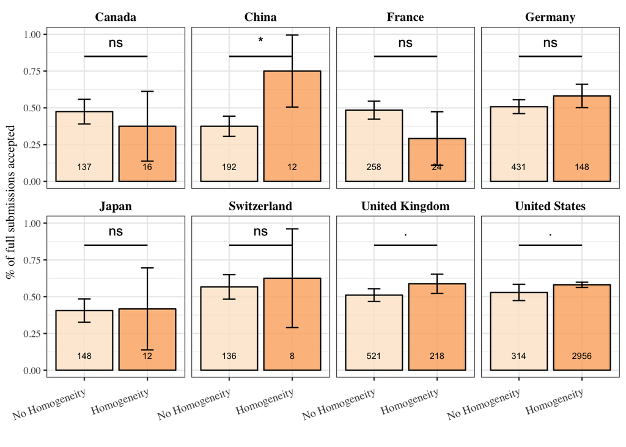

```r
countries <- c("canada", "china", "france", "germany", "japan", "switzerland", "united kingdom", "united states")
sig_list <- list()
for (country in countries) {
  s <- subset(elife, full_decision_made == T & has_full_submission & ca_country == country)
  t <- table(s$ca_country_homophily, s$accepted)
  test = chisq.test(t[, 1:2])
  sig_list[length(sig_list) + 1] <- list(country = test)
}

sig_df <- data.frame(
  ca_country = countries,
  sig = sapply(sig_list, function(l) {sig2ast(l$p.value) })
)

fig7.A <- elife %>%
  filter(full_decision_made & has_full_submission & ca_country %in% countries) %>%
  group_by(ca_country, ca_country_homophily) %>%
  summarize(
    paper_count = n(),
    accept_count = sum(accepted == TRUE, na.rm = T),
    encourage_accept_rate = accept_count / paper_count,
    se = 1.96 * sqrt( (encourage_accept_rate * (1 - encourage_accept_rate)) / paper_count),
    lower = encourage_accept_rate - se,
    upper = encourage_accept_rate + se,
    upper = ifelse(upper > 1, 1, upper)
  ) %>%
  group_by(ca_country) %>%
  mutate(totals = sum(paper_count)) %>%
  ungroup() %>%
  left_join(sig_df) %>%
  #top_n(16, totals) %>% # 8 countries, 3 authorship types per country, therefore first 24 rows
  mutate(ca_country = factor(sapply(as.character(ca_country), simpleCap))) %>%
  # Start ggplot
  ggplot(aes(x = ca_country_homophily, y = encourage_accept_rate, fill = ca_country_homophily)) +
  geom_bar(stat = "identity", position = position_dodge(), color = "black", alpha = 0.8) +
  geom_errorbar(aes(ymin = lower, ymax = upper), color = "black", width = 0.2) +
  geom_text(aes(label = paper_count, y = 0.1), size = 2.5) +
  geom_text(aes(label = sig, x = 1.5, y = 0.95)) +
  geom_segment(aes(x = 1, xend = 2, y = ifelse(sig != "N/A", 0.85, 1.1), yend = ifelse(sig != "N/A", 0.85, 1.1)), color = "black") +
  facet_wrap(~ca_country, nrow = 2, ncol = 4) +
  ylim(0, 1) +
  theme_dakota() +
  guides(fill = FALSE) +
  scale_fill_brewer(palette = "Oranges", labels = c("No Homogeneity", "Homogeneity")) +
  scale_x_discrete(labels = c("No Homogeneity", "Homogeneity")) +
  labs(
    x = "",
    y = "% of full submissions accepted"
  ) +
  theme(
    axis.text.x = element_text(angle = 20, vjust = 1, hjust = 1)
  )

fig7.A
```

And here are the results from the tests used in the graph above

```r
fig7_sig_table <- data.frame(
  country = countries,
  p.value = sapply(sig_list, function(x) x$p.value),
  n = sapply(sig_list, function(x) sum(x$observed)),
  statistic = sapply(sig_list, function(x) x$statistic),
  df = sapply(sig_list, function(x) x$parameter)
)

rownames(fig7_sig_table) <- NULL
fig7_sig_table
```

| country | p.value | n | statistic | df |
| --- | --- | --- | --- | --- |
| canada | 0.62417406 | 153 | 2.400444e-01 | 1 |
| china | 0.02311008 | 204 | 5.160212e+00 | 1 |
| france | 0.11026576 | 282 | 2.550408e+00 | 1 |
| germany | 0.15032115 | 579 | 2.068989e+00 | 1 |
| japan | 1.00000000 | 160 | 0.000000e+00 | 1 |
| switzerland | 1.00000000 | 144 | 1.608755e-30 | 1 |
| united kingdom | 0.06836581 | 739 | 3.321827e+00 | 1 |
| united states | 0.08774438 | 3270 | 2.915276e+00 | 1 |

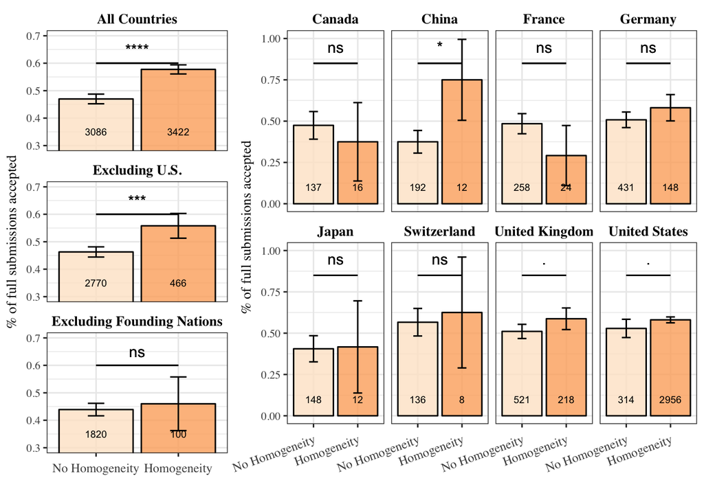

```r
# Get the data, all countries included
d1 <- elife %>%
  filter(full_decision_made & has_full_submission)

# exclude United States
d2 <- elife %>%
  filter(full_decision_made & has_full_submission) %>%
  filter(ca_country != "united states")

# Excluding all founding countries: U.S., U.K., and Germany
d3 <- elife %>%
  filter(full_decision_made & has_full_submission) %>%
  filter(!ca_country %in% c("united states", "united kingdom", "germany"))


# we also need to get the statistical test infomration for each
t1 <- chisq.test(table(d1$ca_country_homophily, d1$accepted))
t2 <- chisq.test(table(d2$ca_country_homophily, d2$accepted))
t3 <- chisq.test(table(d3$ca_country_homophily, d3$accepted))
sig_list <- list(t1, t2, t3)

sig_df <- data.frame(
  type = c("all", "no us", "no founder"),
  sig = sapply(sig_list, function(l) {sig2ast(l$p.value) })
)

d1.summ <- d1 %>%
  group_by(ca_country_homophily) %>%
  summarize(
    paper_count = n(),
    accept_count = sum(accepted == TRUE, na.rm = T),
    encourage_accept_rate = accept_count / paper_count,
    se = 1.96 * sqrt( (encourage_accept_rate * (1 - encourage_accept_rate)) / paper_count),
    lower = encourage_accept_rate - se,
    upper = encourage_accept_rate + se,
    upper = ifelse(upper > 1, 1, upper),
    type = "all"
  )

d2.summ <- d2 %>%
  group_by(ca_country_homophily) %>%
  summarize(
    paper_count = n(),
    accept_count = sum(accepted == TRUE, na.rm = T),
    encourage_accept_rate = accept_count / paper_count,
    se = 1.96 * sqrt( (encourage_accept_rate * (1 - encourage_accept_rate)) / paper_count),
    lower = encourage_accept_rate - se,
    upper = encourage_accept_rate + se,
    upper = ifelse(upper > 1, 1, upper),
    type = "no us"
  )

d3.summ <- d3 %>%
  group_by(ca_country_homophily) %>%
  summarize(
    paper_count = n(),
    accept_count = sum(accepted == TRUE, na.rm = T),
    encourage_accept_rate = accept_count / paper_count,
    se = 1.96 * sqrt( (encourage_accept_rate * (1 - encourage_accept_rate)) / paper_count),
    lower = encourage_accept_rate - se,
    upper = encourage_accept_rate + se,
    upper = ifelse(upper > 1, 1, upper),
    type = "no founder"
  )

fig7.B <- d1.summ %>%
  union(d2.summ) %>%
  union(d3.summ) %>%
  left_join(sig_df, by = "type") %>%
  mutate(type = factor(type,
                       levels = c("all", "no us", "no founder"),
                       labels = c("All Countries", "Excluding U.S.", "Excluding Founding Nations")
                       )
         ) %>%
  ggplot(aes(x = ca_country_homophily, y = encourage_accept_rate, fill = ca_country_homophily)) +
  geom_bar(stat = "identity", position = position_dodge(), color = "black", alpha = 0.8) +
  geom_errorbar(aes(ymin = lower, ymax = upper), color = "black", width = 0.2) +
  geom_text(aes(label = paper_count, y = 0.35), size = 2.5) +
  geom_text(aes(label = sig, x = 1.5, y = 0.65)) +
  geom_segment(aes(x = 1, xend = 2, y = ifelse(sig != "N/A", 0.6, 1.1), yend = ifelse(sig != "N/A", 0.6, 1.1)), color = "black") +
  facet_wrap(~type, nrow = 3) +
  coord_cartesian(ylim = c(0.3, 0.7)) +
  theme_dakota() +
  guides(fill = FALSE) +
  scale_fill_brewer(palette = "Oranges", labels = c("No Homogeneity", "Homogeneity")) +
  scale_x_discrete(labels = c("No Homogeneity", "Homogeneity")) +
  labs(
    x = "",
    y = "% of full submissions accepted"
  )

fig7 <- grid.arrange(fig7.B, fig7.A, ncol = 2, widths = 1:2)
```

```r
ggsave("figures/main/fig_7.tiff", plot = fig7, height = 4, width = 7)
```

```r
fig7.B_sig_table <- data.frame(
  type  = c("all", "no us", "no founer"),
  p.value = sapply(sig_list, function(x) x$p.value),
  n = sapply(sig_list, function(x) sum(x$observed)),
  statistic = sapply(sig_list, function(x) x$statistic),
  df = sapply(sig_list, function(x) x$parameter)
)

rownames(fig7.B_sig_table) <- NULL
fig7.B_sig_table
```

| type | p.value | n | statistic | df |
| --- | --- | --- | --- | --- |
| all | 4.967953e-18 | 6508 | 74.89353039 | 1 |
| no us | 1.741949e-04 | 3236 | 14.09078743 | 1 |
| no founer | 7.579217e-01 | 1920 | 0.09499412 | 1 |

### Presence of author-reviewer national homogeny by country of correposnding author

```r
full <- elife %>%
  filter(has_full_submission) %>%
  group_by(ca_country) %>%
  summarize(
    submissions = n(),
    prop_homogeny = sum(ca_country_homophily, na.rm = T) / submissions
  ) %>%
  arrange(-prop_homogeny) %>%
  top_n(20)
full
```

| ca_country | submissions | prop_homogeny |
| --- | --- | --- |
| united states | 3605 | 0.90513176 |
| united kingdom | 803 | 0.29763387 |
| germany | 641 | 0.25273011 |
| canada | 176 | 0.11363636 |
| south korea | 45 | 0.11111111 |
| south africa | 11 | 0.09090909 |
| france | 310 | 0.07741935 |
| japan | 184 | 0.07608696 |
| australia | 101 | 0.06930693 |
| china | 233 | 0.06437768 |

[output cut: 10 more lines]

```r
write.csv(full, file = "tables/table_SI3.csv")
```

# Supp. Materials

## Figure SI.1

> Figure SI.1 Average number of revisions a full submissions undergoes before a final decision of accept or reject is made. In this case, zero revisions occurs when a full submission is accepted or rejected without a request for any revisions. The dataset records at maximum two revisions, though only a small number of manuscripts remain in revision after two submissions (see figure 1). For this figure, we only include manuscripts for which a final decision is made after zero, one, or two revisions. The left panel shows differences in the average number of revisions by the country of the last author. The right shows the average revisions by the gender of the last author.

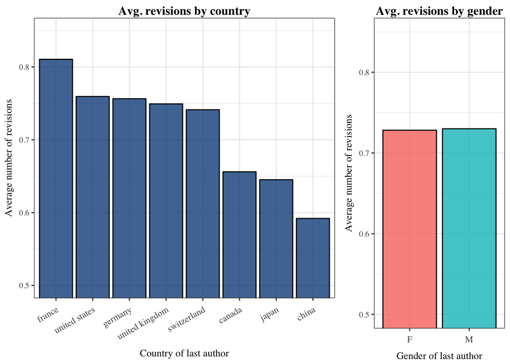

```r
fig_SI.1.A <- elife %>%
  filter(full_decision_made & has_full_submission & la_country %in% countries) %>%
  group_by(la_country) %>%
  summarize(
    avg_revisions = mean(num_revisions)
  ) %>%
  ggplot(aes(x = reorder(la_country, -avg_revisions), y = avg_revisions)) +
  geom_bar(stat = "identity", fill = "dodgerblue4", alpha = 0.8, color = "black") +
  theme_dakota() +
  labs(x = "Country of last author",
       y = "Average number of revisions",
       title = "Avg. revisions by country") +
  coord_cartesian(ylim = c(0.5, 0.85)) +
  theme(
    plot.title = element_text(size = 12, margin = margin(0, 0, 2, 0)),
    axis.text.x = element_text(angle = 30, hjust = 1, vjust = 1)
        )

fig_SI.1.B <- elife %>%
  filter(full_decision_made & has_full_submission & la_gender %in% c("M", "F")) %>%
  group_by(la_gender) %>%
  summarize(
    avg_revisions = mean(num_revisions)
  ) %>%
  ggplot(aes(x = la_gender, y = avg_revisions, fill = la_gender)) +
  geom_bar(stat = "identity", alpha = 0.8, color = "black") +
  theme_dakota() +
  labs(x = "Gender of last author",
       y = "Average number of revisions",
       title = "Avg. revisions by gender") +
  guides(fill = FALSE) +
  coord_cartesian(ylim = c(0.5, 0.85)) +
  theme(plot.title = element_text(size = 12, margin = margin(0, 0, 2, 0)))

fig_SI.1 <- grid.arrange(fig_SI.1.A, fig_SI.1.B, widths = 2:1)
```

```r
fig_SI.1
```

```r
ggsave("figures/supp/fig_SI1.tiff", plot = fig_SI.1, height = 4, width = 7)
```

## Figure SI.2

> Figure SI.2. Proportion of initial submissions, encourage rate, overall accept rate, and accept rate of full submissions by the gender of the corresponding author, first author, and last author. Gender metadata is unavailable for first and last authors of initial submissions that were never submitted as full submissions, therefore these cells remain blank. Authors whose gender is unknown are excluded from analysis. Vertical error bars indicate 95th confidence intervals of the proportion of submitted, encouraged, and accepted initial and full submissions. Asterisks indicate significance level of X2 tests of independence of frequency of encourage and acceptance by gender; “*” = p < 0.05; “ns” = p > 0.05.

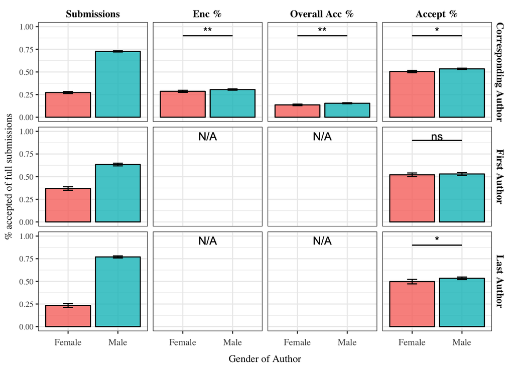

```r
# First, test the encourage rate diffs
s <- subset(elife, initial_decision_made)
t <- table("ca_gender" = s$ca_gender, "encouraged" = s$encouraged)[1:2,]
ca_encouraged <- chisq.test(t[, 1:2])

# Difference in acceptance rates by gender of corresponding author
s <- subset(elife, initial_decision_made & (!has_full_submission | full_decision_made))
t <- table("ca_gender" = s$ca_gender, "encouraged" = s$accepted)[1:2,]
ca_accepted <- chisq.test(t[, 1:2])

# Difference in encourage-acceptance rates by gender of corresponding author
s <- subset(elife, initial_decision_made & full_decision_made)
t <- table("ca_gender" = s$ca_gender, "accepted" = s$accepted)[1:2,]
ca_ea <- chisq.test(t[, 1:2])

# Difference in encourage-acceptance rates by gender of first author
s <- subset(elife, initial_decision_made & full_decision_made)
t <- table("fa_gender" = s$fa_gender, "accepted" = s$accepted)[1:2,]
fa_ea <- chisq.test(t[, 1:2])

# Difference in encourage-acceptance rates by gender of last author
s <- subset(elife, initial_decision_made & full_decision_made)
t <- table("la_gender" = s$la_gender, "accepted" = s$accepted)[1:2,]
la_ea <- chisq.test(t[, 1:2])

# Now we use the results of these tests to construct a table
measurements <- c(rep("submit_rate", 3), rep("encourage_rate", 3), rep("accept_rate", 3), rep("encourage_accept_rate", 3))
author <- rep(c("ca_gender", "fa_gender", "la_gender"), 4)

sig <- c("N/A", "N/A", "N/A", # submit rates, all NA since we don't really compare this
         sig2ast(ca_encouraged$p.value), "N/A", "N/A", # encourage rate
         sig2ast(ca_accepted$p.value), "N/A", "N/A",
         sig2ast(ca_ea$p.value), sig2ast(fa_ea$p.value), sig2ast(la_ea$p.value)
         )
sig_df <- data.frame(measure_key = factor(measurements), author_key = factor(author), sig = sig)

# Now lets save these test results for later
sig_list <- list("Corresponding author enc. rate" = ca_encouraged,
                   "Corresponding author acc. rate" = ca_accepted,
                   "Corresponding author enc-acc rate" = ca_ea,
                   "First author enc-acc rate" = fa_ea,
                   "last author enc-acc rate" = la_ea)


fig_SI.2 <- elife %>%
  filter(initial_decision_made) %>%
  gather(author_key, value = gender, ca_gender, la_gender, fa_gender) %>%
  filter(gender %in% c('M', 'F')) %>%
  group_by(author_key) %>%
  mutate(
    # if not ocnsidering the corr. author, then the count is all full submissions, ie: for when a submission ia made
    total_papers = ifelse(author_key == "ca_gender", n(), sum(has_full_submission))
    )%>%
  group_by(author_key, gender) %>%
  summarize(
        paper_count = n(),
        accept_count = sum(accepted == TRUE, na.rm = T),
        encourage_count = sum(encouraged == TRUE),
        encourage_rate = ifelse(author_key[1] == "ca_gender", encourage_count / n(), NA),
        # this accept rate is the number of accepted papers / number of initial + full submissions
        accept_rate = ifelse(author_key[1] == "ca_gender", accept_count / sum(!has_full_submission | full_decision_made, na.rm = T), NA),
        submit_rate = n() / total_papers[1],
        # this is the number of accepted papers divided by all papers
        encourage_accept_rate = accept_count / sum(has_full_submission & full_decision_made, na.rm = T)
  ) %>%
  ungroup() %>%
  gather(measure_key, value = measurement, submit_rate, encourage_rate, accept_rate, encourage_accept_rate) %>%
  left_join(sig_df, by = c("measure_key", "author_key")) %>%
  mutate(
    author_key = factor(author_key,
                        levels = c("ca_gender", "fa_gender", "la_gender"),
                        labels = c("ca_gender" = "Corresponding Author", "fa_gender" = "First Author", "la_gender" = "Last Author")
                        ),
    measure_key = factor(measure_key,
                         labels = c("submit_rate" = "Submissions", "encourage_rate" = "Enc %", "accept_rate" = "Overall Acc %", "encourage_accept_rate" = "Accept %"),
                         levels = c("submit_rate", "encourage_rate", "accept_rate", "encourage_accept_rate")),
    gender = ifelse(gender == "F", "Female", "Male"),
    standard_error = 1.96 * sqrt( (measurement * (1 - measurement)) / paper_count),
    lower = measurement - standard_error,
    upper = measurement + standard_error
  ) %>%
  ggplot(aes(x = gender, y = measurement, color = factor(gender), shape = factor(gender), fill = factor(gender))) +
  geom_bar(stat = "identity", alpha = 0.8, color = "black") +
  #geom_text(aes(y = 0.08, label = paper_count), size = 2.5, color = "black") +
  #geom_text(aes(x = gender, y = 0.1, label = round(measurement, 3) * 100 ), color = "black") +
  #facet_grid(measure_key ~ author_key) +
  geom_errorbar(aes(ymin = lower, ymax = upper), width = 0.2, color = "black") +
  geom_text(aes(x = 1.5, y = 0.95, label = ifelse(measure_key == "Submissions", "", as.character(sig))), color = "black") +
  geom_segment(aes(x = 1, xend = 2, y = ifelse(sig != "N/A", 0.90, 1.1), yend = ifelse(sig != "N/A", 0.90, 1.1)), color = "black") +
  facet_grid(author_key ~ measure_key) +
  coord_cartesian(ylim = c(0, 1)) +
  theme_dakota() +
  guides(fill = F) +
  labs(
    x = "Gender of Author",
    y = "% accepted of full submissions"
  )

fig_SI.2
```

```r
ggsave("figures/supp/fig_SI2.tiff", plot = fig_SI.2, height = 4, width = 7)
```

## Figure SI.3

> Figure SI.3. Percentage of full submissions that were accepted, shown by the gender of the corresponding, first, and last author, and by the gender composition of the peer reviewers. Text at the base of each bar indicate the number full submissions within each category of reviewer team and authorship gender. Vertical error bars indicate 95th percentile confidence intervals of the proportion of accepted full submissions. Asterisks indicate significance level of X2 tests of independence on frequency of acceptance by gender of author given each team composition; “ns” indicates no observed statistical significance. “*“ = p < 0.05; “ns” = p > 0.05.

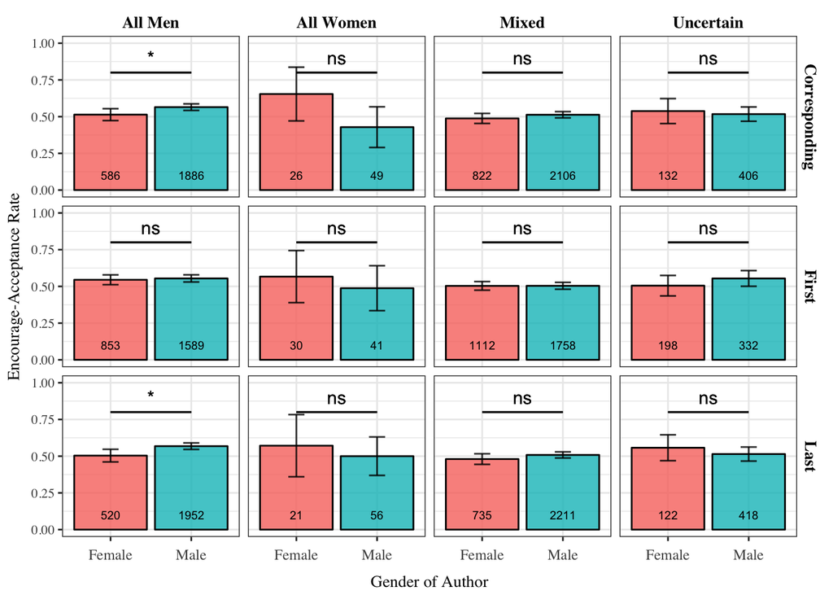

```r
sig_list <- list()
for(comp in c("All Men", "All Women", "Mixed", "Uncertain")) {
  for(gender_var in c("ca_gender", "fa_gender", "la_gender")) {
    if (!is.na(comp)) {
      sub <- subset(elife, initial_decision_made & full_decision_made & composition == comp)[, c("accepted", gender_var)]
      t <- t(table(sub))[1:2,]
      test = chisq.test(t)
      test$n = dim(sub)[1]
      sig_list[length(sig_list) + 1] <- list(test)
    }
  }
}

sig_df <- data.frame(composition = c(rep("All Men", 3), rep("All Women", 3), rep("Mixed", 3), rep("Uncertain", 3)),
                     author_key = rep(c("ca_gender", "fa_gender", "la_gender"), 4),
                     sig = sapply(sig_list, function(test) { sig2ast(test$p.value)})
)

fig_SI.3 <- elife %>%
  filter(initial_decision_made & full_decision_made & !is.na(composition)) %>%
  mutate(total_submissions = n()) %>%
  gather(author_key, value = gender, ca_gender, fa_gender, la_gender) %>%
  filter(gender %in% c("M", "F")) %>%
  group_by(composition, author_key, gender) %>%
  summarize(
    paper_count = n(),
    accept_count = sum(accepted == TRUE),
    acceptance_rate = sum(accepted == TRUE) / paper_count,
    standard_error = 1.96 * sqrt( (acceptance_rate * (1 - acceptance_rate)) / paper_count),
    lower = acceptance_rate - standard_error,
    upper = acceptance_rate + standard_error
  ) %>%
  ungroup() %>%
  left_join(sig_df, by = c("composition", "author_key")) %>%
  mutate(
    author_key = factor(author_key,
                        levels = c("ca_gender", "fa_gender", "la_gender"),
                        labels = c("ca_gender" = "Corresponding", "fa_gender" = "First", "la_gender" = "Last"))
    ,
    gender = ifelse(gender == "M", "Male", "Female")
  ) %>%
  # Start ggplot
  ggplot(aes(x = gender, y = acceptance_rate, fill = gender)) +
  geom_bar(stat = "identity", alpha = 0.8, color = "black") +
  geom_text(aes(y = 0.1, label = paper_count), size = 2.5, color = "black") +
  #geom_text(aes(y = 0.1, label = paste0(round(acceptance_rate, 3) * 100, "%")), size = 2.5, color = "black", position = position_dodge(0.87)) +
  geom_errorbar(aes(ymin = lower, ymax = upper), width = 0.2, color = "black", alpha = 0.8) +
  geom_text(aes(x = 1.5, y = 0.90, label = sig), color = "black") +
  #geom_text(aes(x = gender, y = 0.1, label = round(acceptance_rate, 3) * 100 ), color = "black") +
  geom_segment(aes(x = 1, xend = 2, y = ifelse(sig != "N/A", 0.8, 1.1), yend = ifelse(sig != "N/A", 0.8, 1.1)), color = "black") +
  facet_grid(author_key ~ composition) +
  ylim(0, 1) +
  theme_dakota() +
  guides(fill = F) +
  labs(y = "Encourage-Acceptance Rate",
       x = "Gender of Author"
  )

fig_SI.3
```

```r
ggsave("figures/supp/fig_SI2.tiff", plot = fig_SI.2, height = 4, width = 7)
```

## Figure SI.4

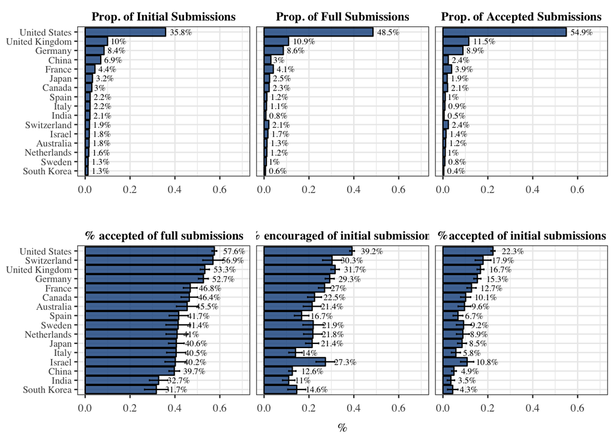

```r
# Its easiest and most efficient to calculate these total values outside of the dplyr chain below
total_submissions <- length(unique(elife$MSNO))
total_full_submissions <- sum(!elife$full_decision_date_isNA, na.rm = T)
total_encouraged <- with(elife, sum(initial_decision_made & encouraged, na.rm = T))
total_accepted <- with(elife, sum(full_decision_made & accepted == T, na.rm = T))

# Firs the first plot, this one will show the proportion that each countrie constitutes the total number of submitted, encouraged, and accepted manuscripts
p1 <- elife %>%
  filter(initial_decision_made & (full_decision_made | full_decision_date_isNA) & !is.na(ca_country)) %>%
  mutate(ca_country = factor(sapply(as.character(ca_country), simpleCap))) %>% # capitalize first letter of country stirngs
  group_by(ca_country) %>%
  summarize(
    paper_count = n(),
    accept_count = sum(accepted == TRUE, na.rm = T),
    encourage_count = sum(encouraged == TRUE, na.rm = T),
    full_submissions = sum(has_full_submission),
    prop_of_full =  full_submissions / total_full_submissions,
    prop_of_initial = paper_count / total_submissions,
    prop_of_encouraged = encourage_count / total_encouraged,
    prop_of_accepted = accept_count / total_accepted
  ) %>%
  group_by(ca_country) %>%
  mutate(totals = sum(paper_count)) %>%
  ungroup() %>%
  top_n(16, totals) %>%
  gather(prop_key, value = prop, prop_of_initial, prop_of_full, prop_of_accepted) %>%
  mutate(prop_key = factor(prop_key,
                           levels = c("prop_of_initial", "prop_of_full", "prop_of_accepted"),
                           labels = c("prop_of_initial" = "Prop. of Initial Submissions",
                                      "prop_of_full" = "Prop. of Full Submissions",
                                      "prop_of_accepted" = "Prop. of Accepted Submissions")),
         ca_country = reorder(ca_country, paper_count)
  ) %>%
  # Start ggplot
  ggplot(aes(x = ca_country, y = prop)) +
  geom_bar(stat = "identity", color = "black", alpha = 0.8, fill = "dodgerblue4", position = position_dodge(1)) +
  geom_text(aes(y = prop, label = paste0(round(prop, 3) * 100, "%")), size = 2.5, hjust = -0.2, family = "Times", position = position_dodge(1)) +
  scale_y_continuous(limits = c(0, 1)) +
  facet_wrap(~prop_key, labeller = labeller(key = labels)) +
  theme_dakota() +
  coord_flip() +
  ylim(0, 0.7) +
  labs(y = "") +
  theme(
    strip.background = element_blank(),
    text = element_text(size = 10, family = "Times"),
    plot.title = element_text(size = 12),
    strip.text = element_text(face = "bold"),
    axis.title.y = element_blank()
  )


p2 <- elife %>%
  filter(initial_decision_made & (full_decision_made | full_decision_date_isNA) & !is.na(ca_country)) %>%
  mutate(ca_country = factor(sapply(as.character(ca_country), simpleCap))) %>% # capitalize first letter of country stirngs
  group_by(ca_country) %>%
  summarize(
    paper_count = n(),
    accept_count = sum(accepted == TRUE, na.rm = T),
    encourage_count = sum(encouraged == TRUE, na.rm = T),
    encourage_rate = encourage_count / paper_count,
    accept_rate = accept_count / sum(!has_full_submission | full_decision_made, na.rm = T),
    encourage_accept_rate = accept_count / sum(has_full_submission & full_decision_made, na.rm = T)
  ) %>%
  group_by(ca_country) %>%
  mutate(totals = sum(paper_count)) %>%
  ungroup() %>%
  top_n(16, totals) %>%
  mutate(
    ca_country = reorder(ca_country, encourage_accept_rate)
  ) %>%
  gather(measure_key, value = measurement, encourage_rate, accept_rate, encourage_accept_rate) %>%
  mutate(measure_key = factor(measure_key,
                           levels = c("encourage_accept_rate", "encourage_rate", "accept_rate"),
                           labels = c("encourage_accept_rate" = "% accepted of full submissions",
                                      "encourage_rate" = "% encouraged of initial submissions",
                                      "accept_rate" = "%accepted of initial submissions"
                                      ))
  ) %>%
  group_by(measure_key) %>%
  mutate(
    se = 1.96 * sqrt(measurement * (1 - measurement) / paper_count),
    lower = measurement - se,
    upper = measurement + se
  ) %>%
  ggplot(aes(x = ca_country, y = measurement)) +
  geom_bar(stat = "identity", color = "black", fill = "dodgerblue4", alpha = 0.8) +
  geom_text(aes(y = measurement, label = paste0(round(measurement, 3) * 100, "%")), size = 2.5, hjust = -0.4, family = "Times") +
  geom_errorbar(aes(ymin = lower, ymax = upper), width = 0.2) +
  facet_wrap(~measure_key, labeller = labeller(key = labels)) +
  theme_dakota() +
  labs(y = "%") +
  coord_flip() +
  ylim(0, 0.7) +
  theme(
    axis.title.y = element_blank()
  )

fig_SI.4 <- grid.arrange(p1, p2)
```

```r
ggsave("figures/supp/fig_SI3.tiff", plot = fig_SI.3, height = 4, width = 7)
```

## Figure SI.5

> Figure SI.5. Proportion of peer reviewer team’s gender compositions by gender of the reviewing editor. Compositions are determined while excluding the reviewing editor from team membership, if they are listed as a peer reviewer.

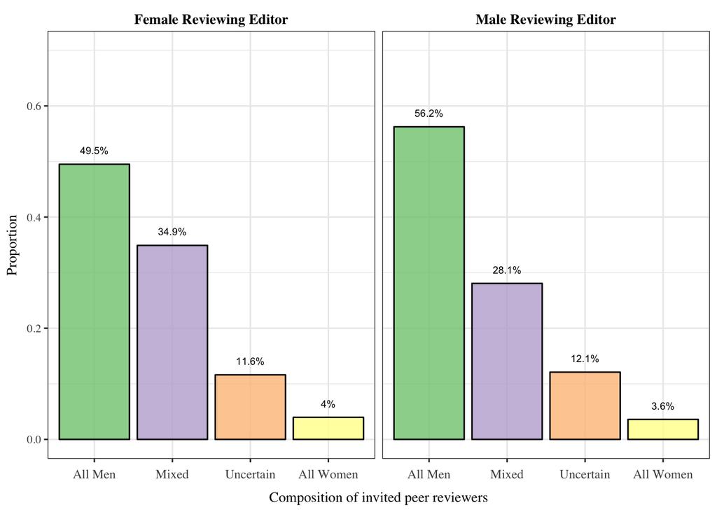

```r
fig_SI.5 <- elife %>%
  filter(bre_gender %in% c("M", "F")) %>%
  mutate(
    bre_gender = ifelse(bre_gender == "M", "Male Reviewing Editor", "Female Reviewing Editor")
    ) %>%
  group_by(bre_gender) %>%
  mutate(total = n()) %>%
  group_by(composition_adj, bre_gender) %>%
  summarize(
    prop = n() / total[1]
  ) %>%
  ungroup() %>%
  mutate(
    composition_adj = reorder(composition_adj, -prop)
  ) %>%
  #arrange(prop) %>%
  ggplot(aes(x = composition_adj, y = prop, fill = composition_adj)) +
  geom_bar(stat = "identity", color = "black", alpha = 0.8) +
  facet_wrap(~bre_gender) +
  geom_text(aes(label = paste0(round(prop, 3) * 100, "%"), y = prop + 0.025), size = 2.5) +
  theme_dakota() +
  scale_fill_brewer(palette = "Accent") +
  guides(fill = F) +
  ylim(0, 0.7) +
  labs(y = "Proportion",
       x = "Composition of invited peer reviewers"
       )

fig_SI.5
```

```r
ggsave("figures/supp/fig_SI5.tiff", plot = fig_SI.5, height = 4, width = 7)
```

## Figure SI.6

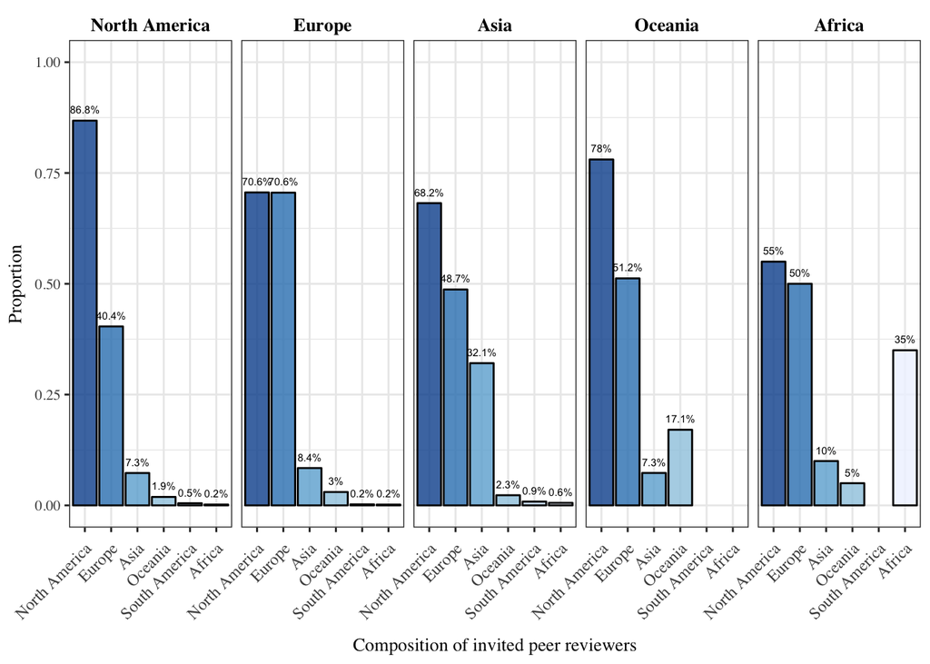

```r
fig_SI.6 <- elife %>%
  filter(has_full_submission & full_decision_made & !is.na(bre_continent)) %>%
  group_by(MSNO) %>%
  mutate(
    num_africa = sum(na.omit(c(reviewer1_continent, reviewer2_continent, reviewer3_continent, reviewer4_continent)) == 1),
    contains_africa = ifelse(bre_is_reviewer & bre_continent == "Africa", num_africa > 1, num_africa > 0),
    num_asia = sum(na.omit(c(reviewer1_continent, reviewer2_continent, reviewer3_continent, reviewer4_continent)) == 2),
    contains_asia = ifelse(bre_is_reviewer & bre_continent == "Asia", num_asia > 1, num_asia > 0),
    num_na = sum(na.omit(c(reviewer1_continent, reviewer2_continent, reviewer3_continent, reviewer4_continent)) == 4),
    contains_na = ifelse(bre_is_reviewer & bre_continent == "North America", num_na > 1, num_na > 0),
    num_eu = sum(na.omit(c(reviewer1_continent, reviewer2_continent, reviewer3_continent, reviewer4_continent)) == 3),
    contains_eu = ifelse(bre_is_reviewer & bre_continent == "Europe", num_eu > 1, num_eu > 0),
    num_sa = sum(na.omit(c(reviewer1_continent, reviewer2_continent, reviewer3_continent, reviewer4_continent)) == 6),
    contains_sa = ifelse(bre_is_reviewer & bre_continent == "South America", num_sa > 1, num_sa > 0),
    num_oceania = sum(na.omit(c(reviewer1_continent, reviewer2_continent, reviewer3_continent, reviewer4_continent)) == 5),
    contains_oceania = ifelse(bre_is_reviewer & bre_continent == "Oceania", num_oceania > 1, num_oceania > 0)
  ) %>%
  group_by(bre_continent) %>%
  mutate(total = n()) %>%
  gather(contains_key, contains, contains_africa, contains_asia, contains_na, contains_eu, contains_sa, contains_oceania) %>%
  group_by(contains_key, contains, bre_continent) %>%
  summarize(
    prop = n() / total[1]
  ) %>%
  ungroup() %>%
  mutate(
    bre_continent = factor(bre_continent, levels = c("North America", "Europe", "Asia", "Oceania", "South America", "Africa")),
    contains_key = factor(contains_key,
                          levels = c("contains_na", "contains_eu", "contains_asia", "contains_oceania", "contains_sa", "contains_africa"),
                          labels = c("contains_na" = "North America", "contains_eu" = "Europe",
                                     "contains_asia" = "Asia", "contains_oceania" = "Oceania",
                                     "contains_sa" = "South America", "contains_africa" = "Africa"))
  ) %>%
  filter(contains == T) %>%
  ggplot(aes(x = contains_key, y = prop, fill = contains_key)) +
  geom_bar(stat = "identity", color = "black", alpha = 0.8) +
  facet_wrap(~bre_continent, ncol = 6) +
  geom_text(aes(label = paste0(round(prop, 3) * 100, "%"), y = prop + 0.025), size = 2) +
  theme_dakota() +
  scale_fill_brewer(palette = "Blues", direction = -1) +
  ylim(0, 1.0) +
   guides(fill = F) +
  theme(
    axis.text.x = element_text(angle = 45, vjust = 1, hjust = 1)
  ) +
  labs(y = "Proportion",
       x = "Composition of invited peer reviewers"
       )


fig_SI.6
```

```r
ggsave("figures/supp/fig_SI6.tiff", plot = fig_SI.6, height = 4, width = 7)
```

## Figure SI.7

> Figure SI.7. Proportion of initial submissions with a female corresponding author by the country of the corresponding author. Includes only countries with at least 200 initial submissions to eLife between 2012 and 2017.

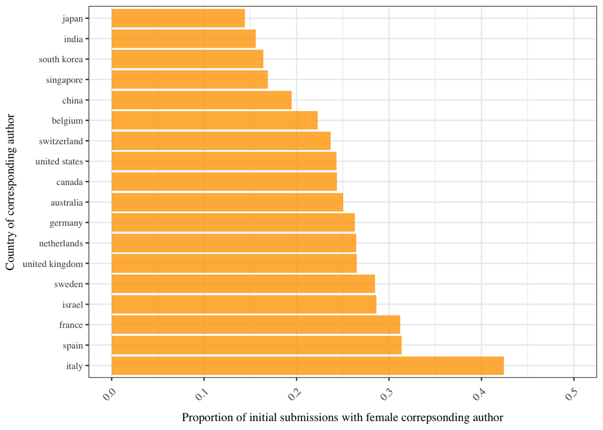

```r
fig_SI.7 <- elife %>%
  group_by(ca_country) %>%
  mutate(total = n()) %>%
  filter(total > 200) %>%
  filter(ca_gender == "F") %>%
  group_by(ca_country) %>%
  summarize(
    prop = n() / total[1]
  ) %>%
  #group_by(ca_gender) %>%
  mutate(
    ca_country = reorder(ca_country, -prop)
  ) %>%
  ggplot(aes(x = ca_country, y = prop)) +
  geom_bar(stat = "identity", alpha = 0.8, fill = "orange") +
  ylim(0, 0.5) +
  coord_flip() +
  theme_dakota() +
  theme(
    axis.text.x = element_text(angle = 45, vjust = 1, hjust = 1)
  ) +
  labs(x = "Country of corresponding author",
       y = "Proportion of initial submissions with female correpsonding author") +
  scale_fill_discrete(labels = c("F" = "Female", "M" = "Male"))

fig_SI.7
```

```r
ggsave("figures/supp/fig_SI7.tiff", plot = fig_SI.7, height = 4, width = 7)
```

### Data used to construct alluvial diagram, figure 1.

```r
decisions <- elife %>%
  group_by(elife$initial_decision, elife$full_decision, elife$rev1_decision, elife$rev2_decision) %>%
  summarize(
    freq = n()
  )


decisions
```

| elife$initial_decision | elife$full_decision | elife$rev1_decision | elife$rev2_decision | freq |
| --- | --- | --- | --- | --- |
| Encourage | Accept | NA | NA | 53 |
| Encourage | Reject | Accept | NA | 10 |
| Encourage | Reject | Reject | Accept | 1 |
| Encourage | Reject | Reject | Reject | 8 |
| Encourage | Reject | Reject | Revise | 4 |
| Encourage | Reject | Reject | NA | 361 |
| Encourage | Reject | Revise | Accept | 76 |
| Encourage | Reject | Revise | Reject | 29 |
| Encourage | Reject | Revise | Revise | 55 |
| Encourage | Reject | Revise | NA | 15 |

[output cut: 26 more lines]

```r
write.csv(decisions, "~/desktop/decisions.csv")
```